The format of this lab follows the same format as the previous ones. Your goal is to predict the value of the third column (which will be missing on the test set) using the techniques we have learned so far.

# Set up

You may need the tokenizers and smodels libraries if you don’t already have them:

```r
library(readr)
library(dplyr)
```

```r
library(ggplot2)
library(viridis)
library(stringi)
library(tokenizers)
library(smodels)
library(glmnet)
president <- read_csv("https://statsmaths.github.io/ml_data/presidents_5.csv")
```

Your assignment will be scored using accuracy. Make sure to submit class labels of either 1, 2, 3, 4 or 5.

# Lab 14

I start by looking at the balance/imbalance in our dataset to get a better idea of the problem at hand. Looking at the data, we see that the highest frequency presidents in our train and valid set are very different order.

```r
table(president$train_id, president$class_name)
```

```
##
##         Dwight D. Eisenhower Harry S Truman Lyndon B. Johnson
##   test                     0              0                 0
##   train                  207             91               274
##   valid                  108            254                53
##
##         Richard M. Nixon Ronald Reagan
##   test                 0             0
##   train               38           210
##   valid              183            86
```

Next, I tokenize the words into 1,2 or 3 word combinations (trigrams) and shingles, setting the frequency of the occurences to be between 1% and 90% of the speeches. Including the shingles improved the validation accuracy of the glmnet so I opted for it.

```r
token_list <- tokenize_ngrams(president$text, n = 3, n_min=1)
token_list_2 <- tokenize_character_shingles(president$text, n_min=1, n=3, strip_non_alphanum = TRUE)

token_df_1 <- term_list_to_df(token_list)
token_df_2 <- term_list_to_df(token_list_2)


X1 <- term_df_to_matrix(token_df_1, min_df = 0.01, max_df = 0.90,
                       scale = TRUE)
X2 <- term_df_to_matrix(token_df_2, min_df = 0.01, max_df = 0.90,
                       scale = TRUE)

X <- cbind(X1, X2)

y <- president$class
X_train <- X[president$train_id == "train",]
X_valid <- X[president$train_id == "valid",]
y_train <- y[president$train_id == "train"]
y_valid <- y[president$train_id == "valid"]
```

Next, I fit a glmnet to the data collected. We see that the min and 1se errors are very slightly different which may mean that a much less complex model may be optimal for our final predictions.

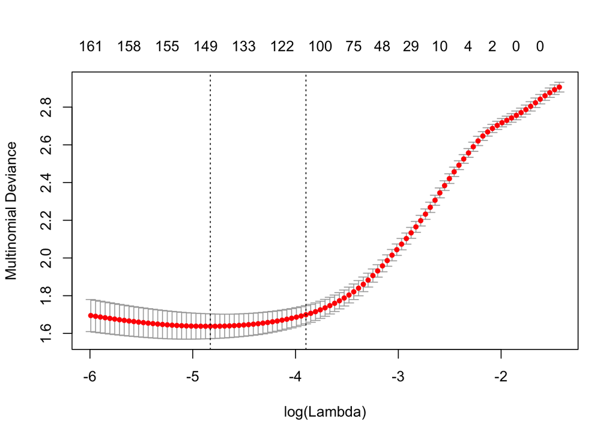

```r
model1 <- cv.glmnet(X_train,y_train, alpha=0.9, nfolds=5, family="multinomial")
plot(model1)
```

```r
coeficients <- coef(model1, s = c(model1$lambda.min, model1$lambda.1se))
```

It seems as though the min lambda model gives us the higher validation set accuracy of about 46% therefore we opt for the min lambda value for our glmnet model.

```r
model1_pred_1se <- predict(model1, newx=X, s = "lambda.1se", type="class")
model1_pred_min <- predict(model1, newx=X, s = "lambda.min", type="class")

tapply(model1_pred_1se == president$class, president$train_id, mean)
```

```
##      test     train     valid
##        NA 0.9536585 0.4444444
```

```r
tapply(model1_pred_min == president$class, president$train_id, mean)
```

```
##      test     train     valid
##        NA 0.9670732 0.4576023
```

```r
president$class_pred <- model1_pred_min
```

Next, we look at some diagnostics of our predictions. We see that the model did a fairly good job of predictin categories 1,3,5 (presidents Eisenhower,Johnson and Reagan). But misclassifies many 2 and 4 (Truman, Nixon). I also notice that the data has many NA values (some of which the model predicted correctly). This makes sense especially when considering that presidents 2,4 are the 2 most frequent in our validation set but 2 of the least frequent in our training set.

```r
table(y=president$class, x = president$class_pred)
```

```
##    x
## y     1   2   3   4   5
##   1 295   2   7   0  11
##   2 110 199  20   4  12
##   3   8   0 312   0   7
##   4  68  11  57  44  41
##   5   6   0  33   1 256
```

# Submission

The code below assumes that you have added a prediction named `class_pred` to every row of the dataset.

```r
submit <- select(president, obs_id, class_pred)
write_csv(submit, "class14_submit.csv")
```

Now, upload this file (ends with “.Rmd”), the HTML output (ends with “.nb.html” or “.html”), and the csv file to GitHub.